# Drug target prediction

Wenyu

1/15/2021

This notebook explores the performance of different type of drug signatures for drug target prediction. Rendering the notebook with pre-computed input takes around 110 seconds.

# 1 Dataset exploration

Check how many drugs are available for supervised target prediction comparison The prediction itself is moved to server batch job codes.

```r
#217
ctrp_drug_list <- res_ctrp2 %>%
  select(-.metric, -estimate, -variance, -input) %>%
  distinct() %>%
  filter(!sample_size <100) %>%
  filter(broad_cpd_id %in% drug_consensus_ctrp$drug) %>%
  filter(!drug_pair) %>%
  select(cpd_smiles,broad_cpd_id, sample_size) %>%
  drop_na() %>%
  group_by(cpd_smiles) %>%
  slice_max(n=1, order_by=sample_size) %>%
  pull(broad_cpd_id)

#57
gdsc_drug_list <- res_gdsc2 %>%
  select(-.metric, -estimate, -variance, -input) %>%
  distinct() %>%
  filter(DRUG_ID %in% drug_consensus_gdsc$drug) %>%
  filter(!sample_size <100) %>%
  select(smiles,DRUG_ID, sample_size) %>%
  drop_na() %>%
  group_by(smiles) %>%
  slice_max(n=1, order_by=sample_size) %>%
  pull(DRUG_ID)

#918  (805, 137)
prism_drug_list <- res_prism2  %>%
  select(-.metric, -estimate, -variance, -input) %>%
  distinct() %>%
  filter(BROAD_ID %in% drug_consensus_prism$drug) %>%
  filter(!sample_size <100) %>%
  select(smiles,BROAD_ID, sample_size) %>%
  drop_na() %>%
  group_by(smiles) %>%
  slice_max(n=1, order_by=sample_size) %>%
  pull(BROAD_ID)

length(intersect(ctrp_drug_list, unique(ctrp_target_binary$drug))) #196
```

```
## [1] 196
```

```r
length(intersect(ctrp_drug_list, unique(ctrp_target_dtc$drug))) #183
```

```
## [1] 183
```

```r
length(intersect(gdsc_drug_list, unique(gdsc_target_binary$drug))) #49
```

```
## [1] 49
```

```r
length(intersect(gdsc_drug_list, unique(gdsc_target_dtc$drug))) #52
```

```
## [1] 52
```

```r
length(intersect(prism_drug_list, unique(prism_target_binary$drug))) #805
```

```
## [1] 805
```

```r
length(intersect(prism_drug_list, unique(prism_target_dtc$drug))) #137
```

```
## [1] 137
```

check how many drugs are available for exploring ess-signature without comparing to other set of features?

```r
#n =488
ctrp_allvalid_list <- res_ctrp2 %>%
  select(-.metric, -estimate, -variance, -input) %>%
  distinct() %>%
  filter(!sample_size <100) %>%
  filter(!drug_pair) %>%
  select(cpd_smiles,broad_cpd_id, sample_size) %>%
  drop_na() %>%
  group_by(cpd_smiles) %>%
  slice_max(n=1, order_by=sample_size) %>%
  pull(broad_cpd_id)

#n= 175
gdsc_allvalid_list <- res_gdsc2 %>%
  select(-.metric, -estimate, -variance, -input) %>%
  distinct() %>%
  filter(!sample_size <100) %>%
  # select(smiles,DRUG_ID, sample_size) %>%
  # drop_na() %>%
  group_by(DRUG_NAME) %>%
  slice_max(n=1, order_by=sample_size) %>%
  pull(DRUG_ID)

length(intersect(ctrp_allvalid_list, unique(ctrp_target_binary$drug))) #360
```

```
## [1] 360
```

```r
length(intersect(ctrp_allvalid_list, unique(ctrp_target_dtc$drug))) #209
```

```
## [1] 209
```

```r
length(intersect(gdsc_allvalid_list, unique(gdsc_target_binary$drug))) #123
```

```
## [1] 123
```

```r
length(intersect(gdsc_allvalid_list, unique(gdsc_target_dtc$drug))) #104
```

```
## [1] 104
```

# 2 Visualization of drug target prediction accuracy

```r
get_acc_summary <- function(acc_df){
  acc_df <- acc_df %>%
    filter(method %in% c("senbased_genesig_comb1", "Consensus_exp_perturb", "structure_ECFP", "structure_MACCS") )

  acc_df$method <-
     factor(acc_df$method,
            levels= c("senbased_genesig_comb1", "Consensus_exp_perturb", "structure_ECFP", "structure_MACCS"),
            labels = c("ConSen-sig", "ConExp-sig", "Fingerprint-ECFP","Fingerprint-MACCS" ))

  acc_df %>%
    group_by(method) %>%
    summarise(acc_mean= mean(acc,na.rm = T), acc_median= median(acc, na.rm = T))
}


get_acc_violin_plot <- function(acc_df){
  acc_df <- acc_df %>%
    filter(method %in% c("senbased_genesig_comb1", "Consensus_exp_perturb", "structure_ECFP", "structure_MACCS") )

  acc_df$method <-
     factor(acc_df$method,
            levels= c("senbased_genesig_comb1", "Consensus_exp_perturb", "structure_ECFP", "structure_MACCS"),
            labels = c("ConSen-sig", "ConExp-sig", "Fingerprint-ECFP","Fingerprint-MACCS" ))
  acc_df %>%
    ggplot(aes(x=method, y=acc, color= method)) +
    geom_violin()+
    stat_summary(fun.data = "mean_cl_boot", geom = "pointrange",
             colour = "black")+
    theme_classic()+
    theme(axis.text.x = element_blank())+
    xlab(label = "")+
    ylab(label = "AUC")+
    # scale_color_manual(name="Cylinders",
    #                  labels=c("ConSen-sig", "ConExp-sig", "Fingerprint-ECFP","Fingerprint-MACCS" ))+
    scale_color_npg()
}
```

https://ggplot2.tidyverse.org/reference/label_bquote.html

```r
acc_df <-
  bind_rows(acc_df_ctrp_binary_fold_cv %>% mutate(Dataset= "CTRP", TargetType= "Primary")) %>%
  bind_rows(acc_df_ctrp_dtcbinary_foldcv %>% mutate(Dataset= "CTRP", TargetType= "Kinome-wide Binarized")) %>%
  # bind_rows(acc_df_ctrp_dtc_foldcv %>% mutate(Dataset= "CTRP", TargetType= "Kinome-wide Continues")) %>%
bind_rows(acc_df_gdsc_binary_fold_cv %>% mutate(Dataset= "GDSC", TargetType= "Primary")) %>%
  bind_rows(acc_df_gdsc_dtcbinary_foldcv %>% mutate(Dataset= "GDSC", TargetType= "Kinome-wide Binarized")) %>%
  # bind_rows(acc_df_gdsc_dtc_foldcv %>% mutate(Dataset= "GDSC", TargetType= "Kinome-wide Continues")) %>%
  filter(method %in% c("senbased_genesig_comb1", "Consensus_exp_perturb", "structure_ECFP", "structure_MACCS") )
  # mutate(Y_names= case_when(TargetTpue %in% "Kinome-wide Continues" ~ "COR"),TRUE~AUC)

acc_df$method <-  factor(
  acc_df$method,
  levels= c("senbased_genesig_comb1", "Consensus_exp_perturb", "structure_ECFP", "structure_MACCS"),
  labels = c("Ess-sig", "Exp-sig", "Fingerprint-ECFP","Fingerprint-MACCS" ))

acc_df$facet = factor(
  acc_df$TargetType,
  levels = c("Primary",
             "Kinome-wide Binarized"
             # "Kinome-wide Continues"
             ),
  labels=    c(
                        "Primary targets",
                        "Kinome targets"
                        # "AUC['binarized kinome targets']",
                        # "COR['continues kinome targets']"
                               ))

acc_df
```

```
## # A tibble: 240 × 7
##    id      id2     acc method           Dataset TargetType facet
##    <chr>   <chr> <dbl> <fct>            <chr>   <chr>      <fct>
##  1 Repeat1 Fold1 0.540 Fingerprint-ECFP CTRP    Primary    Primary targets
##  2 Repeat1 Fold2 0.524 Fingerprint-ECFP CTRP    Primary    Primary targets
##  3 Repeat1 Fold3 0.573 Fingerprint-ECFP CTRP    Primary    Primary targets
##  4 Repeat1 Fold4 0.574 Fingerprint-ECFP CTRP    Primary    Primary targets
##  5 Repeat1 Fold5 0.582 Fingerprint-ECFP CTRP    Primary    Primary targets
##  6 Repeat2 Fold1 0.589 Fingerprint-ECFP CTRP    Primary    Primary targets
##  7 Repeat2 Fold2 0.566 Fingerprint-ECFP CTRP    Primary    Primary targets
##  8 Repeat2 Fold3 0.450 Fingerprint-ECFP CTRP    Primary    Primary targets
##  9 Repeat2 Fold4 0.676 Fingerprint-ECFP CTRP    Primary    Primary targets
## 10 Repeat2 Fold5 0.560 Fingerprint-ECFP CTRP    Primary    Primary targets
## # … with 230 more rows
```

```r
acc_df %>%
  group_by(method,Dataset,TargetType) %>%
  summarise(median_acc= median(acc)) %>%
  filter(TargetType=="Primary")
```

```
## # A tibble: 8 × 4
## # Groups:   method, Dataset [8]
##   method            Dataset TargetType median_acc
##   <fct>             <chr>   <chr>           <dbl>
## 1 Ess-sig           CTRP    Primary         0.648
## 2 Ess-sig           GDSC    Primary         0.608
## 3 Exp-sig           CTRP    Primary         0.613
## 4 Exp-sig           GDSC    Primary         0.548
## 5 Fingerprint-ECFP  CTRP    Primary         0.560
## 6 Fingerprint-ECFP  GDSC    Primary         0.466
## 7 Fingerprint-MACCS CTRP    Primary         0.544
## 8 Fingerprint-MACCS GDSC    Primary         0.429
```

```r
sig_res1 <- acc_df %>%
  nest_by(Dataset,TargetType) %>%
  ungroup() %>%
  mutate(aov_p_value=map_dbl(
    .x = data,
    .f = function(df){
        res= aov(acc~method,data = df)
        res= summary(res)[[1]][[5]][[1]]
        return(res)
    }
                 )) %>%
  mutate(Test_res=map(
    .x = data,
    .f = function(df){
      res=DescTools::DunnettTest(df$acc, g= df$method)
      res= tibble(comparison= row.names(res[[1]]),
                  diff= res[[1]][,1],
                  p.value= res[[1]][,4])
      return(res)
    }
                 )) %>%
  select(-data) %>%
  unnest(cols = c(Test_res))
write_csv(sig_res1, "sig_res1.csv")
sig_res1
```

```
## # A tibble: 12 × 6
##    Dataset TargetType            aov_p_value comparison            diff  p.value
##    <chr>   <chr>                       <dbl> <chr>                <dbl>    <dbl>
##  1 CTRP    Kinome-wide Binarized    4.86e-11 Exp-sig-Ess-sig    -0.0626 4.34e- 7
##  2 CTRP    Kinome-wide Binarized    4.86e-11 Fingerprint-ECFP-… -0.0705 2.95e- 8
##  3 CTRP    Kinome-wide Binarized    4.86e-11 Fingerprint-MACCS… -0.0900 1.68e-11
##  4 CTRP    Primary                  1.20e- 5 Exp-sig-Ess-sig    -0.0387 2.41e- 1
##  5 CTRP    Primary                  1.20e- 5 Fingerprint-ECFP-… -0.0953 4.27e- 4
##  6 CTRP    Primary                  1.20e- 5 Fingerprint-MACCS… -0.119  1.96e- 5
##  7 GDSC    Kinome-wide Binarized    1.41e- 2 Exp-sig-Ess-sig    -0.0490 1.84e- 1
##  8 GDSC    Kinome-wide Binarized    1.41e- 2 Fingerprint-ECFP-… -0.0706 3.17e- 2
##  9 GDSC    Kinome-wide Binarized    1.41e- 2 Fingerprint-MACCS… -0.0867 6.63e- 3
## 10 GDSC    Primary                  9.94e- 7 Exp-sig-Ess-sig    -0.0967 1.86e- 2
## 11 GDSC    Primary                  9.94e- 7 Fingerprint-ECFP-… -0.153  1.25e- 4
## 12 GDSC    Primary                  9.94e- 7 Fingerprint-MACCS… -0.209  7.19e- 7
```

Figure 3a the significance was added manually using inkscape

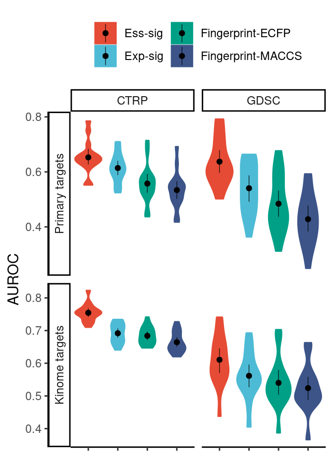

```r
stat.test <- sig_res1 %>%
  mutate(comparison= factor(
    sig_res1$comparison,
    levels = c("Exp-sig-Ess-sig",
            "Fingerprint-ECFP-Ess-sig",
            "Fingerprint-MACCS-Ess-sig"),
    labels = c("Exp-sig_VS_Ess-sig",
            "Fingerprint-ECFP_VS_Ess-sig",
            "Fingerprint-MACCS_VS_Ess-sig") ))%>%
  separate(comparison, "_VS_", into= c("group1","group2")) %>%
  mutate(p.signif= case_when(
    p.value >= 0.05 ~ "ns",
    ((p.value<0.05) & (p.value>=0.01))~ "*",
    ((p.value<0.01) & (p.value>=0.001))~ "**",
    ((p.value<0.001) & (p.value>=0.0001))~ "***",
    p.value <=0.0001  ~ "****"
    ) ) %>%
  mutate(y.position= 0.7)

fig <- acc_df %>%
  ggplot(mapping=aes(x=method, y=acc, color= method, fill= method)) +
  geom_violin()+
  # ggpubr::stat_compare_means(
  #   aes(group=method),label = "p.signif",vjust = 0.4,
  #   method = "t.test",ref.group = "Ess-sig",label.y = 0.75)+
  stat_summary(
    fun.data = "mean_cl_boot",
    geom = "pointrange",
    colour = "black", size= 0.2)+
  theme_classic() +
  theme(axis.text.x = element_blank())+
  ylab(label = "AUROC")+
  xlab(label ="")+
  scale_color_npg()+
  scale_fill_npg()+
  theme(legend.position="top")+
  guides(color= guide_legend(nrow = 2,title.position = "top"))+
  guides(fill= guide_legend(nrow = 2,title.position = "top"))+
  labs(color = "Signature type", fill="Signature type" )+
  facet_grid(facet~Dataset,
             scales = "free",switch="y"
             )+
  theme(legend.title =element_blank())

fig
```

```r
# ggsave(fig, filename = "~/cluster_wrk/drug_moa/supervised_target_pred/fig_res/fig 3A.pdf",width = 3.5,height = 5,bg='transparent')
# ggsave(fig, filename = "~/cluster_wrk/drug_moa/supervised_target_pred/fig_res/fig 3A.png",width = 3.5,height = 5,bg='transparent')
```

# 3 Repurposable pair prioritization

Get predictions for the drugs: use the leave out method since I am going to investigate the selectivity of the predicted targets

training drugs: allvalid drugs with targets from binary table test_drugs, allvalid_drugs

assign the weight of the same drugs to zero in the correlation matrix to avoid data leaking.

```r
ctrpess_drugbank_predictions <- get_predictions(
  sig_data=feature_imp_ridge_ctrp_comb1,
  train_drugs=intersect(ctrp_drug_list, ctrp_target_binary$drug),
  pred_drugs=ctrp_allvalid_list,
  train_label= ctrp_target_binary)

ctrpexp_drugbank_predictions <- get_predictions(
  sig_data=drug_consensus_ctrp,
  train_drugs=intersect(ctrp_drug_list, ctrp_target_binary$drug),
  pred_drugs=drug_consensus_ctrp$drug,
  train_label= ctrp_target_binary)

ctrpmaccs_drugbank_predictions <- get_predictions(
  sig_data=feature_maccs_ctrp,
  train_drugs=intersect(ctrp_drug_list, ctrp_target_binary$drug),
  pred_drugs=feature_maccs_ctrp$drug,
  train_label= ctrp_target_binary,
  similarity= "tahimoto")

ctrpextended_drugbank_predictions <- get_predictions(
  sig_data=feature_extended_ctrp,
  train_drugs=intersect(ctrp_drug_list, ctrp_target_binary$drug),
  pred_drugs=feature_extended_ctrp$drug,
  train_label= ctrp_target_binary,
  similarity= "tahimoto")

gdscess_drugbank_predictions <- get_predictions(
  sig_data=feature_imp_ridge_gdsc_comb1,
  train_drugs=intersect(gdsc_drug_list, gdsc_target_binary$drug),
  pred_drugs=gdsc_allvalid_list,
  train_label= gdsc_target_binary)

gdscexp_drugbank_predictions <- get_predictions(
  sig_data=drug_consensus_gdsc,
  train_drugs=intersect(drug_consensus_gdsc$drug, gdsc_target_binary$drug),
  pred_drugs=drug_consensus_gdsc$drug,
  train_label= gdsc_target_binary)

gdscmaccs_drugbank_predictions <- get_predictions(
  sig_data=feature_maccs_gdsc,
  train_drugs=intersect(feature_maccs_gdsc$drug, gdsc_target_binary$drug),
  pred_drugs=feature_maccs_gdsc$drug,
  train_label= gdsc_target_binary,
  similarity= "tahimoto")

gdscextended_drugbank_predictions <- get_predictions(
  sig_data=feature_extended_gdsc,
  train_drugs=intersect(feature_extended_gdsc$drug, gdsc_target_binary$drug),
  pred_drugs=feature_extended_gdsc$drug,
  train_label= gdsc_target_binary,
  similarity= "tahimoto")

# DTC
ctrpess_dtc_predictions <- get_predictions(
  sig_data=feature_imp_ridge_ctrp_comb1,
  train_drugs=intersect(ctrp_drug_list, ctrp_target_dtc$drug),
  pred_drugs=ctrp_allvalid_list,
  train_label= ctrp_target_dtc)

ctrpexp_dtc_predictions <- get_predictions(
  sig_data=drug_consensus_ctrp,
  train_drugs=intersect(ctrp_drug_list, ctrp_target_dtc$drug),
  pred_drugs=drug_consensus_ctrp$drug,
  train_label= ctrp_target_dtc)

ctrpmaccs_dtc_predictions <- get_predictions(
  sig_data=feature_maccs_ctrp,
  train_drugs=intersect(ctrp_drug_list, ctrp_target_dtc$drug),
  pred_drugs=feature_maccs_ctrp$drug,
  train_label= ctrp_target_dtc,
  similarity= "tahimoto")

ctrpextended_dtc_predictions <- get_predictions(
  sig_data=feature_extended_ctrp,
  train_drugs=intersect(ctrp_drug_list, ctrp_target_dtc$drug),
  pred_drugs=feature_extended_ctrp$drug,
  train_label= ctrp_target_dtc,
  similarity= "tahimoto")

gdscess_dtc_predictions <- get_predictions(
  sig_data=feature_imp_ridge_gdsc_comb1,
  train_drugs=intersect(gdsc_drug_list, gdsc_target_dtc$drug),
  pred_drugs=gdsc_allvalid_list,
  train_label= gdsc_target_dtc)

gdscexp_dtc_predictions <- get_predictions(
  sig_data=drug_consensus_gdsc,
  train_drugs=intersect(drug_consensus_gdsc$drug, gdsc_target_dtc$drug),
  pred_drugs=drug_consensus_gdsc$drug,
  train_label= gdsc_target_dtc)

gdscmaccs_dtc_predictions <- get_predictions(
  sig_data=feature_maccs_gdsc,
  train_drugs=intersect(feature_maccs_gdsc$drug, gdsc_target_dtc$drug),
  pred_drugs=feature_maccs_gdsc$drug,
  train_label= gdsc_target_dtc,
  similarity= "tahimoto")

gdscextended_dtc_predictions <- get_predictions(
  sig_data=feature_extended_gdsc,
  train_drugs=intersect(feature_extended_gdsc$drug, gdsc_target_dtc$drug),
  pred_drugs=feature_extended_gdsc$drug,
  train_label= gdsc_target_dtc,
  similarity= "tahimoto")
save.image("~/cluster_scratch/forward_modelling/supervisedpredictedtargets.RData")
```

now prepare sen matrix and target similiarity matrix

```r
load("~/cluster_scratch/forward_modelling/supervisedpredictedtargets.RData")
## Predicted target space similiarity
get_similarity_mat <- function(mat){
   cor((mat), method = "spearman")
}

ctrpess_drugbank_predictions_cormat <- get_similarity_mat(ctrpess_drugbank_predictions)
ctrpexp_drugbank_predictions_cormat <- get_similarity_mat(ctrpexp_drugbank_predictions)
ctrpmaccs_drugbank_predictions_cormat <- get_similarity_mat(ctrpmaccs_drugbank_predictions)
ctrpextended_drugbank_predictions_cormat <- get_similarity_mat(ctrpextended_drugbank_predictions)

gdscess_drugbank_predictions_cormat <- get_similarity_mat(gdscess_drugbank_predictions)
gdscexp_drugbank_predictions_cormat <- get_similarity_mat(gdscexp_drugbank_predictions)
gdscmaccs_drugbank_predictions_cormat <- get_similarity_mat(gdscmaccs_drugbank_predictions)
gdscextended_drugbank_predictions_cormat <- get_similarity_mat(gdscextended_drugbank_predictions)

ctrpess_dtc_predictions_cormat <- get_similarity_mat(ctrpess_dtc_predictions)
ctrpexp_dtc_predictions_cormat <- get_similarity_mat(ctrpexp_dtc_predictions)
ctrpmaccs_dtc_predictions_cormat <- get_similarity_mat(ctrpmaccs_dtc_predictions)
ctrpextended_dtc_predictions_cormat <- get_similarity_mat(ctrpextended_dtc_predictions)

gdscess_dtc_predictions_cormat <- get_similarity_mat(gdscess_dtc_predictions)
gdscexp_dtc_predictions_cormat <- get_similarity_mat(gdscexp_dtc_predictions)
gdscmaccs_dtc_predictions_cormat <- get_similarity_mat(gdscmaccs_dtc_predictions)
gdscextended_dtc_predictions_cormat <- get_similarity_mat(gdscextended_dtc_predictions)

## Sensitivity space similiarity
sen_ctrp_mat <- ctrp_data %>%
  select(broad_cpd_id, sensitivity) %>%
  unnest(sensitivity) %>%
  select(-apparent_ec50_umol) %>%
  filter(DepMap_ID %in% ces1$DepMap_ID) %>%
  group_by(DepMap_ID, broad_cpd_id) %>%
  summarize(area_under_curve= median(area_under_curve,na.rm = T)) %>%
  ungroup() %>%
  pivot_wider(id_cols = DepMap_ID, names_from=broad_cpd_id , values_from=area_under_curve)
sen_ctrp_cor_mat <- cor(x = as.matrix(sen_ctrp_mat %>% select(-DepMap_ID)),
                          use = "pairwise.complete.obs" ,
                          method= "spearman")

sen_gdsc_mat <- gdsc_data %>%
  select(DRUG_ID, sensitivity) %>%
  unnest(sensitivity) %>%
  select(-LN_IC50) %>%
  group_by(DepMap_ID, DRUG_ID) %>%
  summarize(AUC= median(AUC,na.rm = T)) %>%
  ungroup() %>%
  pivot_wider(id_cols = DepMap_ID, names_from=DRUG_ID , values_from=AUC)
sen_gdsc_cor_mat <-   cor(x = as.matrix(sen_gdsc_mat %>% select(-DepMap_ID)),
                          use = "pairwise.complete.obs" ,
                          method= "spearman")

## putative target space similarity
get_similarity_mat_tahimoto <- function(predictors_mat){

  predictors_mat[predictors_mat<0.4] <- 0
  predictors_mat[predictors_mat>=0.4] <- 1
  cor_mat = 1- as.matrix(vegan::vegdist(x = (predictors_mat),method = "jaccard",upper = F))
  cor_mat[is.nan(cor_mat)] <- 0
  return(cor_mat)
}


tar_ctrp_cor_mat_drugbank <- get_similarity_mat_tahimoto(get_target_mat(ctrp_target_binary))
```

```
##   method          from
##   print.nullmodel parsnip
```

```r
tar_ctrp_cor_mat_dtc <- get_similarity_mat_tahimoto(get_target_mat(ctrp_target_dtc %>% filter(binding_score>0.4) %>% select(-binding_score)))
```

```
## argument.
```

```r
tar_gdsc_cor_mat_drugbank <- get_similarity_mat_tahimoto(get_target_mat(gdsc_target_binary))
```

```
## argument.
```

```r
tar_gdsc_cor_mat_dtc <- get_similarity_mat_tahimoto(get_target_mat(gdsc_target_dtc %>% filter(binding_score>0.4) %>% select(-binding_score)))
```

```
## argument.
```

```r
source('~/cluster_wrk/drug_moa/supervised_target_pred/function/get_longtibble_from_cormat.R')

pairlevel_comparison_ctrp_drugbank <-
 get_longtibble_from_cormat(
   tar_ctrp_cor_mat_drugbank,
   metric="rank_percentage_pairwise") %>%
  rename(tar =value) %>%
  inner_join(
    get_longtibble_from_cormat(sen_ctrp_cor_mat) %>%
      rename(sen =value),
    by= c("drug1", "drug2")
    ) %>%
  inner_join(
    get_longtibble_from_cormat(ctrpess_drugbank_predictions_cormat) %>%
      rename(ess =value),
    by= c("drug1", "drug2")
    ) %>%
  inner_join(
    get_longtibble_from_cormat(ctrpexp_drugbank_predictions_cormat) %>% rename(exp= value),
    by= c("drug1", "drug2")
    ) %>%
  inner_join(
    get_longtibble_from_cormat(ctrpextended_drugbank_predictions_cormat) %>%
      rename(extended= value),
        by= c("drug1", "drug2")
    ) %>%
  inner_join(
    get_longtibble_from_cormat(ctrpmaccs_drugbank_predictions_cormat) %>%
      rename(maccs= value),
        by= c("drug1", "drug2")
    ) %>%
  inner_join(ctrp_data %>% select(broad_cpd_id, target_or_activity_of_compound, cpd_name), by= c("drug1"= "broad_cpd_id")) %>%
  inner_join(ctrp_data %>% select(broad_cpd_id, target_or_activity_of_compound, cpd_name), by= c("drug2"= "broad_cpd_id")) %>%
  arrange(drug1,drug2)
```

```
## [1] "Rank percentage pairwise returned"
## [1] "Rank percentage pairwise returned"
## [1] "Rank percentage pairwise returned"
## [1] "Rank percentage pairwise returned"
## [1] "Rank percentage pairwise returned"
## [1] "Rank percentage pairwise returned"
```

```r
pairlevel_comparison_ctrp_dtc <-
 get_longtibble_from_cormat(
   tar_ctrp_cor_mat_dtc,
   metric="rank_percentage_pairwise") %>%
  rename(tar =value) %>%
  inner_join(
    get_longtibble_from_cormat(sen_ctrp_cor_mat) %>%
      rename(sen =value),
    by= c("drug1", "drug2")
    ) %>%
  inner_join(
    get_longtibble_from_cormat(ctrpess_dtc_predictions_cormat) %>%
      rename(ess =value),
    by= c("drug1", "drug2")
    ) %>%
  inner_join(
    get_longtibble_from_cormat(ctrpexp_dtc_predictions_cormat) %>% rename(exp= value),
    by= c("drug1", "drug2")
    ) %>%
  inner_join(
    get_longtibble_from_cormat(ctrpextended_dtc_predictions_cormat) %>%
      rename(extended= value),
        by= c("drug1", "drug2")
    ) %>%
  inner_join(
    get_longtibble_from_cormat(ctrpmaccs_dtc_predictions_cormat) %>%
      rename(maccs= value),
        by= c("drug1", "drug2")
    ) %>%
  inner_join(ctrp_data %>% select(broad_cpd_id, target_or_activity_of_compound, cpd_name), by= c("drug1"= "broad_cpd_id")) %>%
  inner_join(ctrp_data %>% select(broad_cpd_id, target_or_activity_of_compound, cpd_name), by= c("drug2"= "broad_cpd_id")) %>%
  arrange(drug1,drug2)
```

```
## [1] "Rank percentage pairwise returned"
## [1] "Rank percentage pairwise returned"
## [1] "Rank percentage pairwise returned"
## [1] "Rank percentage pairwise returned"
## [1] "Rank percentage pairwise returned"
## [1] "Rank percentage pairwise returned"
```

```r
pairlevel_comparison_gdsc_drugbank <- get_longtibble_from_cormat(tar_gdsc_cor_mat_drugbank) %>%
  rename(tar =value) %>%
  inner_join(
    get_longtibble_from_cormat(sen_gdsc_cor_mat) %>%
      rename(sen =value),
    by= c("drug1", "drug2")
    ) %>%
  inner_join(
    get_longtibble_from_cormat(gdscess_drugbank_predictions_cormat) %>%
      rename(ess =value),
    by= c("drug1", "drug2")
    ) %>%
  inner_join(
    get_longtibble_from_cormat(gdscexp_drugbank_predictions_cormat) %>%
      rename(exp= value),
    by= c("drug1", "drug2")
    ) %>%
  inner_join(
    get_longtibble_from_cormat(gdscextended_drugbank_predictions_cormat) %>%
      rename(extended= value),
        by= c("drug1", "drug2")
    ) %>%
  inner_join(
    get_longtibble_from_cormat(gdscmaccs_drugbank_predictions_cormat) %>%
      rename(maccs= value),
        by= c("drug1", "drug2")
    ) %>%
  mutate_at(c("drug1","drug2"), as.integer) %>%
    inner_join(gdsc_data %>% select(DRUG_ID, PATHWAY_NAME, DRUG_NAME), by= c("drug1"= "DRUG_ID")) %>%
  inner_join(gdsc_data %>% select(DRUG_ID, PATHWAY_NAME, DRUG_NAME), by= c("drug2"= "DRUG_ID")) %>%
  mutate_at(c("drug1","drug2"), as.character)
```

```
## [1] "Rank percentage pairwise returned"
## [1] "Rank percentage pairwise returned"
## [1] "Rank percentage pairwise returned"
## [1] "Rank percentage pairwise returned"
## [1] "Rank percentage pairwise returned"
## [1] "Rank percentage pairwise returned"
```

```r
pairlevel_comparison_gdsc_dtc  <- get_longtibble_from_cormat(tar_gdsc_cor_mat_dtc) %>%
  rename(tar =value) %>%
  inner_join(
    get_longtibble_from_cormat(sen_gdsc_cor_mat) %>%
      rename(sen =value),
    by= c("drug1", "drug2")
    ) %>%
  inner_join(
    get_longtibble_from_cormat(gdscess_dtc_predictions_cormat) %>%
      rename(ess =value),
    by= c("drug1", "drug2")
    ) %>%
  inner_join(
    get_longtibble_from_cormat(gdscexp_dtc_predictions_cormat) %>%
      rename(exp= value),
    by= c("drug1", "drug2")
    ) %>%
  inner_join(
    get_longtibble_from_cormat(gdscextended_dtc_predictions_cormat) %>%
      rename(extended= value),
        by= c("drug1", "drug2")
    ) %>%
  inner_join(
    get_longtibble_from_cormat(gdscmaccs_dtc_predictions_cormat) %>%
      rename(maccs= value),
        by= c("drug1", "drug2")
    ) %>%
  mutate_at(c("drug1","drug2"), as.integer) %>%
  inner_join(gdsc_data %>% select(DRUG_ID, PATHWAY_NAME, DRUG_NAME), by= c("drug1"= "DRUG_ID")) %>%
  inner_join(gdsc_data %>% select(DRUG_ID, PATHWAY_NAME, DRUG_NAME), by= c("drug2"= "DRUG_ID")) %>%
  mutate_at(c("drug1","drug2"), as.character)
```

```
## [1] "Rank percentage pairwise returned"
## [1] "Rank percentage pairwise returned"
## [1] "Rank percentage pairwise returned"
## [1] "Rank percentage pairwise returned"
## [1] "Rank percentage pairwise returned"
## [1] "Rank percentage pairwise returned"
```

```r
# check how often drugpair is prioritized?
# pairlevel_comparison_ctrp_drugbank %>% summary()
# pairlevel_comparison_ctrp_dtc %>% summary()
# pairlevel_comparison_gdsc_drugbank %>% summary()
# pairlevel_comparison_gdsc_dtc %>% summary()
#
# apply(pairlevel_comparison_ctrp_drugbank %>% select_at(5:8), MARGIN = 2, function(x){sum(x>0.95)})
#
# tmp <- pairlevel_comparison_ctrp_drugbank %>%
#   pivot_longer(cols= 5:8, names_to = "type", values_to= "rank_percentage")
#
# kruskal.test(type~rank_percentage,data= tmp)
# pairwise.wilcox.test(tmp$rank_percentage, tmp$type,
#                  p.adjust.method = "BH")
```

add a plot like this: for the same threshold. http://www.sthda.com/english/articles/24-ggpubr-publication-ready-plots/76-add-p-values-and-significance-levels-to-ggplots/

```r
figdata1 <- pairlevel_comparison_ctrp_drugbank %>%
  filter(sen >0.95) %>%
  filter(tar >0.95) %>%
  mutate(drug_pair_name= str_c(cpd_name.x, cpd_name.y,sep = "  ")) %>%
  mutate(drug_pair_name = as.factor(drug_pair_name) ) %>%
  mutate(drug_pair_name = fct_reorder(drug_pair_name,ess))%>%
  select(drug_pair_name, ess:maccs, target_or_activity_of_compound.x) %>%
  pivot_longer(ess:maccs, names_to="method", values_to= "value",names_repair = "unique")


figdata2 <- pairlevel_comparison_ctrp_dtc %>%
  filter(sen >0.95) %>%
  filter(tar >0.95) %>%
  mutate(drug_pair_name= str_c(cpd_name.x, cpd_name.y,sep = "  ")) %>%
  mutate(drug_pair_name = as.factor(drug_pair_name) ) %>%
  mutate(drug_pair_name = fct_reorder(drug_pair_name,ess))%>%
  select(drug_pair_name, ess:maccs, target_or_activity_of_compound.x) %>%
  pivot_longer(ess:maccs, names_to="method", values_to= "value",names_repair = "unique")

figdata3 <-
 pairlevel_comparison_gdsc_drugbank %>%
  filter(tar >0.90) %>%
  filter(sen> 0.90) %>%
  mutate(drug_pair_name= str_c(DRUG_NAME.x, DRUG_NAME.y,sep = "  ")) %>%
  mutate(drug_pair_name = as.factor(drug_pair_name) ) %>%
  mutate(drug_pair_name = fct_reorder(drug_pair_name,ess))%>%
  select(drug_pair_name, ess:maccs, PATHWAY_NAME.x) %>%
  pivot_longer(ess:maccs, names_to="method", values_to= "value",names_repair = "unique")

figdata4 <- pairlevel_comparison_gdsc_dtc %>%
  filter(tar >0.90) %>%
  filter(sen > 0.90) %>%
  mutate(drug_pair_name= str_c(DRUG_NAME.x, DRUG_NAME.y,sep = "  ")) %>%
  mutate(drug_pair_name = as.factor(drug_pair_name) ) %>%
  mutate(drug_pair_name = fct_reorder(drug_pair_name,ess))%>%
  select(drug_pair_name, ess:maccs, PATHWAY_NAME.x) %>%
  pivot_longer(ess:maccs, names_to="method", values_to= "value",names_repair = "unique")

fig_data <- figdata1 %>% mutate(Dataset= "CTRP", TargetType= "Primary target") %>%
  bind_rows(figdata2 %>% mutate(Dataset= "CTRP", TargetType= "Kinome target")) %>%
  bind_rows(figdata3 %>% mutate(Dataset= "GDSC", TargetType= "Primary target")) %>%
  bind_rows(figdata4 %>% mutate(Dataset= "GDSC", TargetType= "Kinome target"))
fig_data %>% group_by(method, Dataset,TargetType) %>% summarize(median_perc= median(value))
```

```
## # A tibble: 16 × 4
## # Groups:   method, Dataset [8]
##    method   Dataset TargetType     median_perc
##    <chr>    <chr>   <chr>                <dbl>
##  1 ess      CTRP    Kinome target        0.976
##  2 ess      CTRP    Primary target       0.934
##  3 ess      GDSC    Kinome target        0.954
##  4 ess      GDSC    Primary target       0.908
##  5 exp      CTRP    Kinome target        0.724
##  6 exp      CTRP    Primary target       0.684
##  7 exp      GDSC    Kinome target        0.659
##  8 exp      GDSC    Primary target       0.609
##  9 extended CTRP    Kinome target        0.725
## 10 extended CTRP    Primary target       0.664
## 11 extended GDSC    Kinome target        0.779
## 12 extended GDSC    Primary target       0.772
## 13 maccs    CTRP    Kinome target        0.732
## 14 maccs    CTRP    Primary target       0.642
## 15 maccs    GDSC    Kinome target        0.695
## 16 maccs    GDSC    Primary target       0.721
```

```r
fig_data %>% count(method, Dataset,TargetType)
```

```
## # A tibble: 16 × 4
##    method   Dataset TargetType         n
##    <chr>    <chr>   <chr>          <int>
##  1 ess      CTRP    Kinome target     70
##  2 ess      CTRP    Primary target   159
##  3 ess      GDSC    Kinome target     23
##  4 ess      GDSC    Primary target    29
##  5 exp      CTRP    Kinome target     70
##  6 exp      CTRP    Primary target   159
##  7 exp      GDSC    Kinome target     23
##  8 exp      GDSC    Primary target    29
##  9 extended CTRP    Kinome target     70
## 10 extended CTRP    Primary target   159
## 11 extended GDSC    Kinome target     23
## 12 extended GDSC    Primary target    29
## 13 maccs    CTRP    Kinome target     70
## 14 maccs    CTRP    Primary target   159
## 15 maccs    GDSC    Kinome target     23
## 16 maccs    GDSC    Primary target    29
```

```r
sig_res2 <- fig_data %>%
  nest_by(Dataset,TargetType) %>%
  ungroup() %>%
  # mutate(aov_p_value=map_dbl(
  #   .x = data,
  #   .f = function(df){
  #       res= aov(value~method,data = df)
  #       res= summary(res)[[1]][[5]][[1]]
  #       return(res)
  #   }
  #                )) %>%
  mutate(Test_res=map(
    .x = data,
    .f = function(df){
        # res= aov(acc~method,data = df)
        # res= TukeyHSD(res, which = "method", paired=T) %>% tidy()
      # res=pairwise.wilcox.test(df$value,
      #                          g= df$method,paired= T,p.adjust.method = "BH") %>% tidy()
      res=rstatix::wilcox_test(
        data=df, formula=value~method,
        ref.group = "ess",
        # p.adjust.method = "BH",
        paired= T) %>%
        as_tibble()
      # res= tibble(comparison= row.names(res[[1]]),
      #             diff= res[[1]][,1],
      #             p.value= res[[1]][,4])
      return(res)
    }
                 )) %>%
  select(-data) %>%
  unnest(cols = c(Test_res))
write_csv(sig_res2, "sig_res2.csv")
sig_res2
```

```
## # A tibble: 12 × 11
##    Dataset TargetType     .y.   group1 group2      n1    n2 statistic        p
##    <chr>   <chr>          <chr> <chr>  <chr>    <int> <int>     <dbl>    <dbl>
##  1 CTRP    Kinome target  value ess    exp         70    70     2246. 4.29e- 9
##  2 CTRP    Kinome target  value ess    extended    70    70     2119  5.12e- 8
##  3 CTRP    Kinome target  value ess    maccs       70    70     2224. 1.27e- 9
##  4 CTRP    Primary target value ess    exp        159   159    11504. 9.2 e-19
##  5 CTRP    Primary target value ess    extended   159   159    10844  4.11e-16
##  6 CTRP    Primary target value ess    maccs      159   159    11352. 1.32e-18
##  7 GDSC    Kinome target  value ess    exp         23    23      221  2   e- 3
##  8 GDSC    Kinome target  value ess    extended    23    23      187  1.42e- 1
##  9 GDSC    Kinome target  value ess    maccs       23    23      232  3   e- 3
## 10 GDSC    Primary target value ess    exp         29    29      352. 4   e- 3
## 11 GDSC    Primary target value ess    extended    29    29      344  6   e- 3
## 12 GDSC    Primary target value ess    maccs       29    29      348  4   e- 3
## # … with 2 more variables: p.adj <dbl>, p.adj.signif <chr>
```

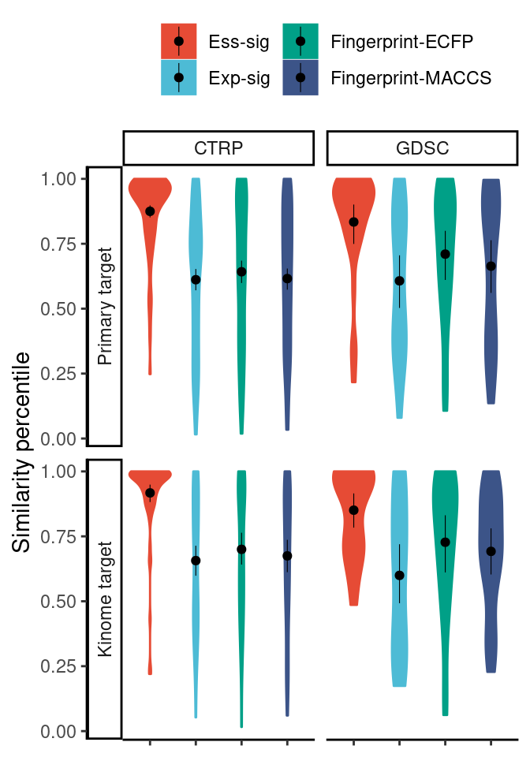

```r
# my_comparisons <- list(c("Ess-sig", "Exp-sig"), c("Ess-sig", "Fingerprint-ECFP"), c("Ess-sig", "Fingerprint-MACCS"))
fig <- fig_data %>%
    mutate(method= factor(method,
                      levels = c("ess","exp", "extended", "maccs"),
                      labels= c("Ess-sig", "Exp-sig", "Fingerprint-ECFP","Fingerprint-MACCS" )
                      ) )%>%
  mutate(TargetType= factor(
    TargetType,
    levels = c("Primary target", "Kinome target")
                               )) %>%
  ggplot(
    mapping = aes(
      # x= fct_reorder(method,value, median,.desc=T),
      x= method,
      y = value,
      fill = method, color= method)
         ) +
  geom_violin()+
  # ggpubr::stat_compare_means(
  #   aes(group=method),label = "p.signif",
  #   method = "wilcox.test",
  #   ref.group = 1,label.y=1.1,
  #   # comparisons = my_comparisons,
  #   # tip.length = 0.01,bracket.size=0.1,
  #   vjust = 0.4)+
  stat_summary(fun.data = "mean_cl_boot", geom = "pointrange",
           colour = "black",size=0.2)+
  theme_classic()+
  scale_fill_npg()+
  scale_color_npg()+
  ylab("Similarity percentile")+
  guides(fill= guide_legend(nrow = 2))+
  facet_grid(cols = vars(Dataset), rows = vars(TargetType),scales = "free",switch = "y")+
  theme(legend.title = element_blank(),legend.position="top",axis.text.x=element_blank(), axis.title.x=element_blank())
fig
```

```r
# ggsave(fig, filename = "~/cluster_wrk/drug_moa/supervised_target_pred/fig_res/supplementary figure1.pdf",width = 3.5,height = 5,bg = 'transparent')
```

Figure 3B Highlight of three drug pairs is added mannually using inkscape

```r
figdata <- pairlevel_comparison_ctrp_drugbank %>%
  filter(target_or_activity_of_compound.x== target_or_activity_of_compound.y) %>%
  filter(sen >0.99) %>%
  filter(tar ==1) %>%
  mutate(target_or_activity_of_compound.x =
           recode(target_or_activity_of_compound.x,
                  "inhibitor of BCL2, BCL-xL, and BCL-W" =
                    "BCL family",
                  "inhibitor of bromodomain (BRD) and extra-C terminal domain (BET) proteins" = "others",
                  "inhibitor of HDAC1, HDAC2, HDAC3, HDAC6, and HDAC8" = "HDAC family",
                  "inhibitor of nicotinamide phosphoribosyltransferase" = "others",
                  "inhibitor of polo-like kinase 1 (PLK1)" = "PLK1",
                  "inhibitor of topoisomerase II" = "TOP2A",
                  "inhibitor of BRAF" = "BRAF",
                  "inhibitor of mTOR" = "MTOR",
                  "inhibitor of EGFR and HER2" = "EGFR and HER2"
                  ))%>%
  mutate(drug_pair_name= str_c(cpd_name.x, cpd_name.y,sep = "  ")) %>%
  mutate(drug_pair_name = as.factor(drug_pair_name) ) %>%
  mutate(drug_pair_name = fct_reorder(drug_pair_name,ess))%>%
  select(drug_pair_name, ess:maccs, target_or_activity_of_compound.x) %>%
  pivot_longer(ess:maccs, names_to="method", values_to= "value",names_repair = "unique") %>%
  mutate(method= factor(
    method,
    levels = c("ess","exp", "extended", "maccs"),
    labels= c("Ess-sig", "Exp-sig", "Fingerprint-ECFP","Fingerprint-MACCS" )
    ))

levels(figdata$target_or_activity_of_compound.x) <- c("BCL family","BRAF","EGFR and HER2","HDAC family","MTOR","PLK1","TOP2A","others" )

pmain <- figdata %>%
  ggplot(mapping = aes(x=  drug_pair_name,y = value, color= method) ) +
  geom_point()+
  geom_line(aes(group= method))+
  theme_classic()+
  theme(legend.position="bottom")+
  guides(color= guide_legend(nrow = 4,title.position = "top"))+
  xlab("")+
  ylab("Similarity percentile" )+
  labs(color = "Prediction Method")+
  coord_flip()+
  scale_color_npg()+
  scale_y_continuous(position = "right")+
  scale_x_discrete(position = "top")+
  guides(fill= guide_legend(nrow = 4))+
  theme(legend.position="top",legend.title = element_blank())

# xbox <- figdata %>%
#   ggplot(
#     mapping = aes(
#       x= fct_reorder(method,value, median,.desc=T),
#       y = value, fill = method )
#          ) +
#   geom_boxplot(outlier.shape = NA)+
#   theme_classic()+
#   coord_flip()+
#   scale_fill_npg()+
#   theme(legend.position="none")

ybar <- figdata %>%
  ggplot(aes(x= drug_pair_name, fill= target_or_activity_of_compound.x),
      y =1 ) +
  geom_bar()+
  theme_classic()+
  coord_flip()+
    # theme(legend.position="none")+
  guides(fill= guide_legend(nrow = 4,title.position = "top"))+
  labs(fill = "Drug mechanism")+
  scale_fill_discrete(labels=c("BCL family","BRAF","EGFR and HER2","HDAC family","MTOR","PLK1","TOP2A","Others" ))+
  theme(legend.title = element_blank())

# p1 <- cowplot::insert_xaxis_grob(pmain, xbox, grid::unit(0.1, "null"), position = "bottom")
p2 <- cowplot::insert_yaxis_grob(pmain, ybar+theme(legend.position="top"), grid::unit(0.05, "null"), position = "right")

# extract the legend from one of the plots
legend <- cowplot::get_legend(
  ybar
)

# add the legend to the row we made earlier. Give it one-third of
# the width of one plot (via rel_widths).
fig <- cowplot::plot_grid(p2, legend, rel_heights = c(5, 1),nrow = 2)
```

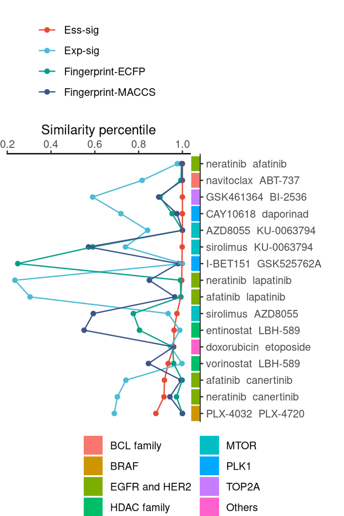

```r
# cowplot::ggdraw(p2)
fig
```

```r
# ggsave(fig, filename = "~/cluster_wrk/drug_moa/supervised_target_pred/fig_res/fig 3B.pdf",width = 4,height = 6,bg = 'transparent')
```